# Homework 03

Author

Zoe Stopfer

Published

March 3, 2026

```r
# reading in packages
library(tidyverse)
library(here)
library(flextable)
library(janitor)
salinity <- read_csv(here("Data", "salinity-pickleweed.csv")) # reading salinity data
my_data <- read_csv(here("Data", "JJMood4.csv")) |> # read in JJ Mood and make into a object
  clean_names() # clean column names
```

https://github.com/ZS-25-bit/ENVS-193DS_homework-03.git

# Problem 1. Slough Soil Salinity

## a.

Pearson’s correlation and Spearman rank correlation are appropriate tests to determine the strength of the relationship between Salinity and California pickleweed biomass because correlation can be used independently of a linear model because the 2 variables are related to each other. Pearson’s correlation is a parametric test that would show the linear relationship between slough soil salinity and pickleweed biomass. Spearman rank correlation is a non-parametric test that would show the monotonic relationship between slough soil salinity and pickleweed biomass.

## b.

```r
ggplot(data = salinity, # use the salintiy data frame
       aes(x = pickleweed, # x-axis
           y = salinity_mS_cm,)) + # y-axis
  geom_point(color = "palegreen3") + # adding points and changin color
  labs(x = "California Picklweed Biomass(g)", # relabelling the x-axis
       y = "Salinity(mS/cm)", # and the y-axis
       title = "As Pickleweed Biomass Growth Increases Slough Salintiy Increases") # adding title
```

[figure not shown]

```r
theme_gray() # changing theme
```

[output not shown]

[output cut: 299 more lines]

[output not shown]

## c.

```r
ggplot(data = salinity, # use the salintiy data frame
       aes(x = pickleweed, # x-axis
           y = salinity_mS_cm,)) + # y-axis
  geom_point(color = "orchid4") + # adding points and changin color
  labs(x = "California Picklweed Biomass(g)", # relabelling the x-axis
       y = "Salinity(mS/cm)", # and the y-axis
       title = "As Pickleweed Biomass Growth Increases Slough Salintiy Increases") # adding title
```

[figure not shown]

```r
theme_gray() # changing theme
```

[output not shown]

[output cut: 299 more lines]

[output not shown]

```r
cor.test(salinity$salinity_mS_cm,salinity$pickleweed, # adding in data frame and columns
         method = "spearman") # this spearman test
```

```
    Spearman's rank correlation rho

data:  salinity$salinity_mS_cm and salinity$pickleweed
S = 824, p-value = 0.003426
alternative hypothesis: true rho is not equal to 0
sample estimates:
      rho
0.5928854
```

The test I ran was the Spearman rank correlation. The assumptions I checked was if there were 1) independent observations and 2) a monotonic relationship between variables. The independent observations in the problem were the slough soil salinity and the pickleweed biomass. The monotonic relationship can be seen in the scatterplot where the dots are following a consistent direction of a curve going up. Since the data is related to each and it aligns with our assumptions, Spearman rank correlation was a appropriate test.

## d.

To evaluate the strength of the relationship between pickleweed biomass and soil salinity, I used a Spearman rank correlation test. Based off the test, we found a moderate relationship between pickleweed biomass and soil salinity ( Spearman ρ = 0,59, S = 824, p = 0.003, α = 0.05).

## e.

Based of the results of the test, we can conclude that the pickleweed biomass increases when the solute soil salinity increases. The graph shows that the data moves in a upward curve as both mS/cm increases when g increases. If we want to restore the population of pickleweed, we should plant them in soil with higher salinity.

## f.

```r
ggplot(data = salinity, # use the salintiy data frame
       aes(x = pickleweed, # x-axis
           y = salinity_mS_cm,)) + # y-axis
  geom_point(color = "aquamarine4") + # adding points and changin color
  labs(x = "California Picklweed Biomass(g)", # relabelling the x-axis
       y = "Salinity(mS/cm)", # and the y-axis
       title = "As Pickleweed Biomass Growth Increases Slough Salintiy Increases") # adding title
```

[figure not shown]

```r
theme_gray() # changing theme
```

[output not shown]

[output cut: 299 more lines]

[output not shown]

```r
ggplot(data = salinity,
       aes(x = pickleweed)) + # x-axis
  # first layer: histogram
  geom_histogram(bins = 6, # bins from Rice Rule (approximate)
                 fill = "orange",
                 color = "black") +
  theme_minimal() +
  labs(x = "Calinfornia Picklweed Biomass(g)", # naming x and y axis
       y = "Salinity(mS/cm)")
```

[figure not shown]

```r
 cor.test(salinity$salinity_mS_cm,salinity$pickleweed, # adding in data frame and columns
         method = "pearson") # this pearson's test
```

```
    Pearson's product-moment correlation

data:  salinity$salinity_mS_cm and salinity$pickleweed
t = 2.8979, df = 21, p-value = 0.008605
alternative hypothesis: true correlation is not equal to 0
95 percent confidence interval:
 0.1568265 0.7757682
sample estimates:
      cor
0.5344778
```

# Problem 2. Personal data

## a.

```r
ggplot(data = my_data, # use my_data frame
       aes(x = attendance)) + #add x-axis
  geom_histogram(stat = "count", #  creates a histogram
                 fill = "#FF4500", # fill in bar with color
                 color = "darkorchid3") + # outline bar
  facet_wrap(~mood_category) + # separated by each mood
  labs(title = "Mood Based on Going/Not Going to Jiu Jitsu", # add title
       x = "Attendance", # label x-axis
       y = "Frequency") + # label y-axis

  theme_grey()+ # change theme
  theme(legend.position = "none") # remove legend
```

[figure not shown]

```r
ggplot(data = my_data, # use my_data data frame
       aes(x = dates, # create x-axis and y-axis
           y = mood_category,
           color = mood_category)) + # color mood_category
  geom_point() + # adding points
  labs( x = "Date", # relabelling x, y, title, and color
        y = "Mood",
        title = "Mood Throughout Time",
        color = "Mood Category") +
  theme_grey() # change theme
```

[figure not shown]

## b.

**Figure 1. Going/Not Going to Jiu Jitsu:** Columns represent counts of attendance in regards of going or not going to jiu Jitsu. Distributions of attendance are represented in four panels based on my emotion at the end of day in regards to attendance: HEP “high energy positive”(top left), HEU” high energy unpleasant” (top right), LEP “low energy positive” (bottom left), and LEU ” low energy unpleasant”(bottom right) .

# Problem 3. Affective visualization

## a.

For my affective visualization, it could look like a collage/ scrapbook. Since I have four different mood categories, I wanted to represent each mood with a color. From those colors, I would find images of items that fall in those colors and glue them in order from how I felt each day. I wanted to glue the pictures also in a zig zag shape to represent ” Z” for Zoe, since this is my data set.

## b.

[figure not shown]

## c.

[figure not shown]

## d.

In my piece I wanted to use day-to-day items to show how much influence our day-to-day mood has on us. Anything can influence our mood throughout the day, so does attending jiu jitsu really make that big of a difference? This is what I wanted to represent in my visualization. My influence is Pinterest. I enjoy grouping photos together that fit a certain theme, and seeing others on the Internet scrapbook. I myself am not a great artist, so I thought scrapbooking would be perfect to still let me be creative as well not humiliate myself to others with my drawing skills. Honestly, my process was just a light bulb moment. I kept on thinking what I could do, without having to paint and draw with making it seem dull and scrapbooking was the thing that called me.

## e.

https://docs.google.com/presentation/d/1baZvH3nevBYd-IbRNbMper1oahUeJJI5jOKi6UShWcI/edit?usp=sharing

# Problem 4. Statistical critique

## a.

ANOVA is a statistical test included in this paper. The response variable is the attitudes on electric vs. gas cars. The predictor variable is the personal statics of the car owners vs. non-car owners.

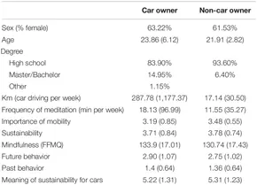

## b.

The table above shows people demographics that could influence the person feeling towards electric cars and the whole idea of sustainability. Knowing what could influence a person decision before and after helped the reseachers understand how they can appeal to different audiences.

## c.

When it comes to visual clutter, they did fine, nothing spectacular. They bolded the words “car owners” and “non-car owners” at the top to represent the 2 main groups they are looking at. After that, on the left side they created new lines for each thing they took into account. The table is clean and makes sense.

## d.

I think overall, the table is clean looking and easy to understand. The numbers itself become a little confusing, so I would add units to make it clear on what the numbers represent/ how to measure each one. The table is plain as well, so I would provide more color to help make it more visually pleasing.